# Comparison script for SoilR model structures

Jeffrey Beem-Miller

1  
jbeem@bgc-jena.mpg.de

# Notes:

1. bulk & respired 14C used for contraints
- three time points for bulk 14C (2001, 2009, 2019)
- two time points for respired CO2 (2001, 2019)
2. steady-state C stocks (mean of 2001, 2009 stock data) used to determine inputs

*This script requires the following input: obs.bulk.14c, obs.resp.14c, obs.Cstock*

# Workflow

1. Fit models by eye for initial parameter estimates
2. Run modfit using bulk and respired 14C time series data
3. Run bayesian parameter optimization
4. Reject models w/ stocks outside ±2SE of measured values
- Then what?
5. Adjust inputs w/ modeled stocks and reject models w/ unrealistic inputs
   - If inputs are not realistic [how to come up with realistic ranges?], may have to implement some constraints on parameter optimization, e.g. if (In > max | In < min) { error } else { fit pars}. Could calculate rejection rate associated with this process…
6. Compare models using AIC; other metrics? E.g. collinearity of parameters, ssr, bias, etc.
7. Get ages and transit times from “best fit” models, e.g. lowest AIC value
8. Compare distribution of ages/transit times with age distribution from density fractionation, thermal fractionation
9. Compare ages, transit times, to mineral characteristics (PCM, minC proportion, etc.)
10. Assess model structure/complexity [objective metrics here?]

# Questions

1. How to set acceptable ranges for inputs?
2. How to deal with lag times? Would be nice to avoid fitting a lag parameter. Options: could set lag by depth, but likely the optimal lag value will vary by site.

**Should copy relevant code for preparing obs.bulk.14c, obs.resp.14c**

# load pre-built bulk, respired 14C objs

# Load initial parameter lists (1p, 2pp, 2ps, 3pp, 3ps)

# Optimize parameter sets

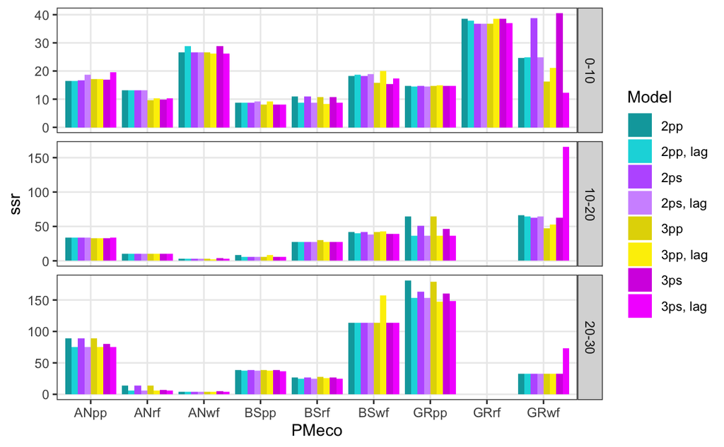

[output not shown]

[output not shown]

For the 2pp models the sites ANpp 0-10 and BSwf 10-20 & 20-30 had much higher inputs than the other sites. For the 2ps models it’s the same, with the addition of GRwf 10-20. Sites ANpp 0-10 and BSwf 20-30 also have anomalously high mean ages. All of the sites with high inputs have transit times ~ 1 yr (TT for ANpp 0-10 = 9 yr), in contrast to values ranging from 60 yrs to hundreds of yrs.

Inputs for 3pp models not much different from 2pp models, alhough there is a tendency to be slightly greater.

[output not shown]

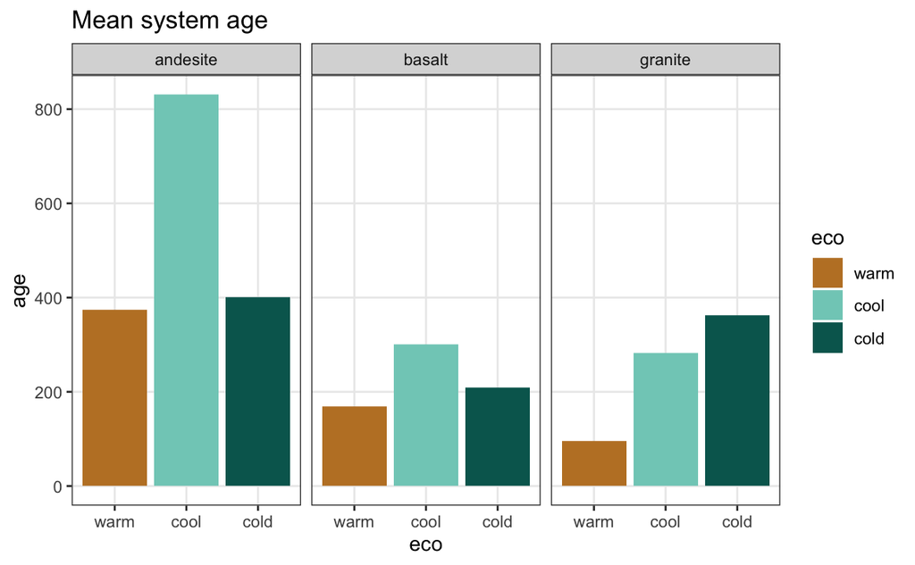

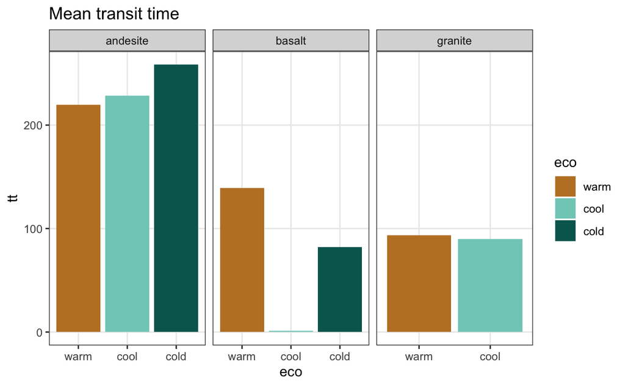

[output not shown]

[output not shown]

# Ages & transit times

Fits for the 2pp and 2ps models were similar across the 0-10 cm depth layer. The only noticable exceptions were for the GRwf and GRrf sites. For the GRrf site, the fit for the 2pp model was essentially a one pool model, with nearly identical *tau* values of 1/170 for the fast and slow pools. In contrast, *tau* for the fast pool in the 2ps model fit at the GRrf site was 1, while the slow pool tau was 1/170. For the GRwf site, the 2pp fit had tau values of 21 and 152 for fast and slow pools, respectively, while the 2ps taus were smaller (longer turnover time): 57 and 1075 respectively.